# matplotlib_example3

## Asset Backed Securities Ratings Over Time

Was curious to see how those securities initially rated AAA fared over time - a fair number were downgraded during the crisis, but did they stay that way? Probably not, given the rise in upgrades after the crisis. While probably home-equity/subprime/res BC (pick whatever you want to call the category) were most affected, wanted to focus just on consumer ABS first.

```python
import pandas as pd
import numpy as np

# loading the ABS data and getting rid of anything before 2000 (quality control). Also get rid of those fully
# paid off securities
df = pd.read_csv('data/getRatingOutstandingUSABS.csv')
df = df[df['OutstandingQuarter'] > '1999Q4']
df = df[df['OutstandingUSDMillions'] != 0]
```

### Some rating coverage statistics:

Some caveats: I don't include those ratings that the rating agencies actively decide not to rate as being rated. 'No rating' is the same as 'unrated'. There are a tiny proportion of securities among the 'rated' category that are technically Withdrawn ratings, but since rating agencies usually withdraw ratings before payoff, the overall amounts impacted are quite small. These figures also don't include notional/io/exchangeable tranches, either.

When doing this analysis, I was rather surprised that S&P edged out over Moody's in rated securities. It's quite close, though.

```python
# let's just get issuance
issuance = df.copy()
issuance.drop_duplicates('IssueTranche', inplace=True)
all_securities = issuance['IssuanceUSDMillions'].sum()
moodys = issuance[issuance['OriginalMoodys'] != 'NR']['IssuanceUSDMillions'].sum()
sp = issuance[issuance['OriginalSP'] != 'NR']['IssuanceUSDMillions'].sum()
fitch = issuance[issuance['OriginalFitch'] != 'NR']['IssuanceUSDMillions'].sum()

print('From the period of 2000 to 2018,')
print('Moodys rated {:.2f}% of all ABS securities by $ amount'.format(moodys/all_securities*100))
print('Standard and Poor\'s rated {:.2f}% of all ABS securities by $ amount'.format(sp/all_securities*100))
print('Fitch rated {:.2f}% of all ABS securities by $ amount'.format(fitch/all_securities*100))
```

```
From the period of 2000 to 2018,
Moodys rated 73.82% of all ABS securities by $ amount
Standard and Poor's rated 74.72% of all ABS securities by $ amount
Fitch rated 59.57% of all ABS securities by $ amount
```

Across the entire dataset, I filtered out just to look at securities initially rated AAA/Aaa by at least one rating agency (in this case, either Moody's, Fitch, or S&P), so this will not account for performance of those securities initially rated below Aaa/AAA and were upgraded or for those that have been rated by another rating agency (e.g., KBRA, DBRS).

```python
# let's aggregate outstanding by quarter and just filter out those initially rated AAA/Aaa
outstanding_by_quarter = df.groupby(['OutstandingQuarter', 'CollateralType', 'IssuanceRatingBucket2',
                                     'OutstandingRatingBucket2'])['IssuanceUSDMillions', 'OutstandingUSDMillions'].sum().reset_index()
outstandingAAA = outstanding_by_quarter[outstanding_by_quarter['IssuanceRatingBucket2'] == '01. Aaa\AAA']
outstandingAAA.head()
```

|  | OutstandingQuarter | CollateralType | IssuanceRatingBucket2 | OutstandingRatingBucket2 | IssuanceUSDMillions | OutstandingUSDMillions |
| --- | --- | --- | --- | --- | --- | --- |
| 0 | 2000Q1 | ABS - Auto | 01. Aaa\AAA | 01. Aaa\AAA | 134802.927044 | 95807.796569 |
| 1 | 2000Q1 | ABS - Auto | 01. Aaa\AAA | 05. NR | 1396.000000 | 1396.000000 |
| 14 | 2000Q1 | ABS - Credit Card | 01. Aaa\AAA | 01. Aaa\AAA | 189249.847131 | 186187.551333 |
| 15 | 2000Q1 | ABS - Credit Card | 01. Aaa\AAA | 02. Aa\AA | 725.000000 | 419.887778 |
| 16 | 2000Q1 | ABS - Credit Card | 01. Aaa\AAA | 05. NR | 2304.750000 | 2304.750000 |

I decided to take a look for auto in particular, since equipment and auto are the likeliest classes to see some sort of ratings change during the crisis (whereas student loan and credit cards are less likely to see them, since they have mitigating factors that stabilize their pool quality). The esoteric category includes too many differing underlying assets and structures to draw much of a conclusion about them.

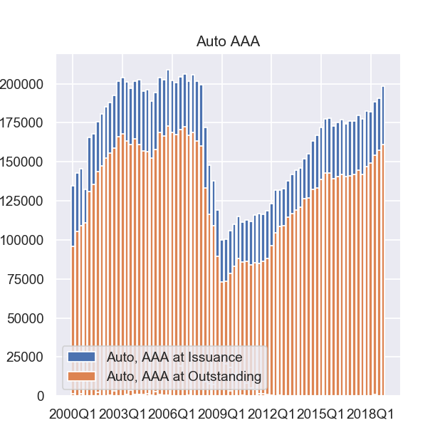

```python
# let's graph just auto
import matplotlib.pyplot as plt
from matplotlib.widgets import Slider
import matplotlib.ticker as ticker
import seaborn as sns
%matplotlib notebook

auto = outstandingAAA[outstandingAAA['CollateralType'] == 'ABS - Auto']

# first chart
sns.set()
fig, ax = plt.subplots(figsize=(5,5))
ax.set_title('Auto AAA')
ax.set_ylabel('$ millions')
plt.bar(auto['OutstandingQuarter'], auto['IssuanceUSDMillions'], label = 'Auto, AAA at Issuance')
plt.bar(auto['OutstandingQuarter'], auto['OutstandingUSDMillions'], label = 'Auto, AAA at Outstanding')
plt.xticks(auto['OutstandingQuarter'])
ax.xaxis.set_major_locator(ticker.MultipleLocator(12))
ax.legend(loc='lower left')
```

Well, we have some idea of how much of any originally AAA/Aaa rated time stays AAA/Aaa rated over time. What about in any particular quarter? Matplotlib doesn't have a *huge* library for animations, but a button clickthrough and update does work just to visualize. May want to try this whole thing by asset class and by rating over time in a better library for visualizations, e.g., dash or bokeh or something. The way that matplotlib handles stacked bars seems kind of suboptimal.

Anyway, after viewing through the Auto and Equipment category, you can see the downgrades right after the crisis (2008Q4 onward), and then gradually upgrades and payoffs collapse these non AAA categories out.

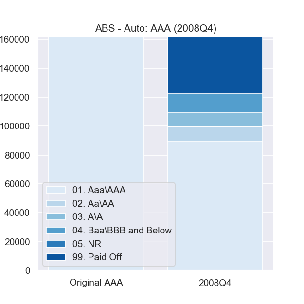

```
6
```

```python
# set up the second chart
fig2, ax2 = plt.subplots(figsize=(5,5))
collateral_choice = 'ABS - Auto'

def make_chart(c_t, q_e):
    # some global variables since hadn't planned that far in the ntoebook
    global fig2
    global ax2
    global plt
    global outstandingAAA

    # fixed colors palette - just to keep the ratings consistent colors
    colors = {'': '#dbe9f6', '01. Aaa\AAA': '#dbe9f6', '02. Aa\AA': '#bad6eb',
          '03. A\A': '#89bedc', '04. Baa\BBB and Below': '#539ecd', '05. NR': '#2b7bba', '99. Paid Off': '#0b559f'}

    collateral_type = c_t
    quarter_end = q_e

    # get all of the specific collateral type at the specific quarter
    subclass_issue = outstandingAAA[(outstandingAAA['CollateralType'] == collateral_type) &
                                (outstandingAAA['OutstandingQuarter'] == quarter_end)]
    x_axis = ['Original AAA', quarter_end]

    # list all the ratings the AAA has been downgraded to or stayed unchanged
    ratings = subclass_issue['OutstandingRatingBucket2'].tolist()
    ratings.append('99. Paid Off')
    ratings.insert(0, '')

    ratings_outstanding = subclass_issue['OutstandingUSDMillions'].tolist()
    paid_off = subclass_issue['IssuanceUSDMillions'].sum() - subclass_issue['OutstandingUSDMillions'].sum()
    ratings_outstanding.append(paid_off)
    ratings_outstanding.insert(0, 0) # this accounts for original amount at issuance
    ratings_issuance = []
    ratings_issuance.append(subclass_issue['IssuanceUSDMillions'].sum())

    # append 0s to deal with left stacked bar without any non AAA ratings
    [ratings_issuance.append(0) for x in range(len(ratings_outstanding)-1)]

    # build the charting elements
    ratings_io = list(zip(ratings_issuance,ratings_outstanding))

    ax2.set_title('{}: AAA ({})'.format(collateral_type, quarter_end))
    ax2.set_ylabel('$ millions')
    for i in range(len(ratings)):
        if i == 0:
            plt.bar(x_axis, ratings_io[i], label = ratings[i], color = colors[ratings[i]])
            stacked_sum = np.array(ratings_io[0])
        else:
            plt.bar(x_axis, ratings_io[i], label = ratings[i], bottom = stacked_sum, color = colors[ratings[i]])
            stacked_sum += np.array(ratings_io[i])
    ax2.legend(loc='lower left')
    plt.draw()

chart_counter = 0
quarters = outstandingAAA.OutstandingQuarter.unique()
make_chart(collateral_choice, '2000Q1')
plt.show()

def onclickdown(event):
    global chart_counter
    global quarters

    if chart_counter == len(quarters)-1:
        chart_counter = 0
    else:
        chart_counter += 1
    ax2.cla()
    make_chart(collateral_choice, quarters[chart_counter])

# on click down, the chart updates and iterates through to the next quarter.
fig2.canvas.mpl_connect('button_press_event', onclickdown)
```